# PS2

Morgan Taylor, Caleb Donoho, Vaishnavi Srinivasan

1/18/2018

```r
knitr::opts_chunk$set(echo = FALSE, warning=FALSE)
#install.packages("NHANES")
```

# Question 1

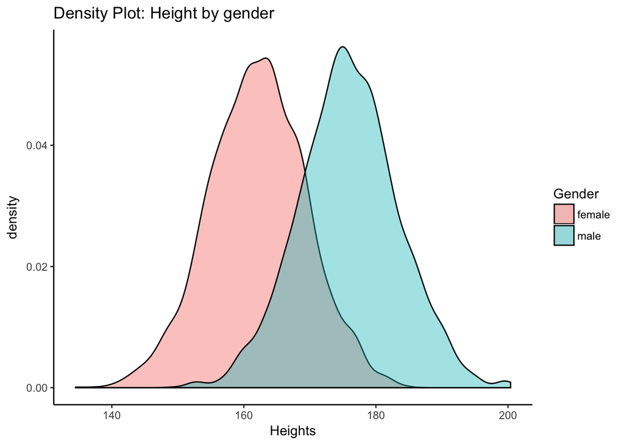

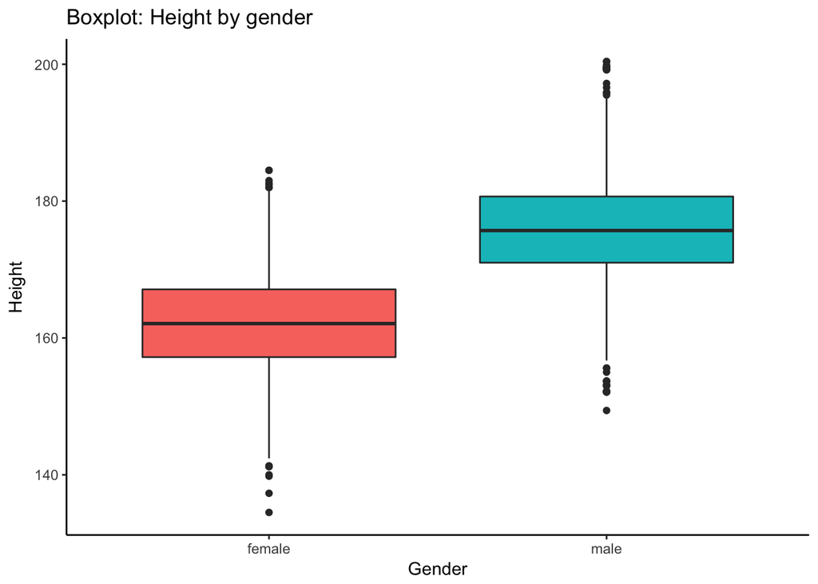

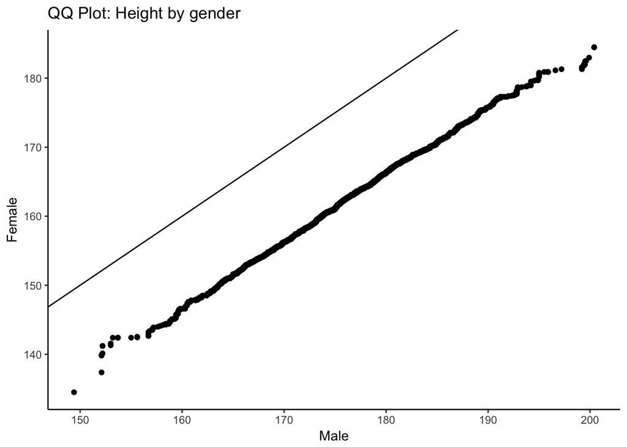

Based on the density plot, boxplot and QQ plots shown above we can see that the distribution is well approximated by an additive shift. This is an additive shift because the two distributions (based on the density plot) have the same shape and spread, but different centers. In the QQ plot we also see that the data points are approximately parallel to the x=y line. The magnitude of the shift is approximately 13 to 15 cm.

# Question 2

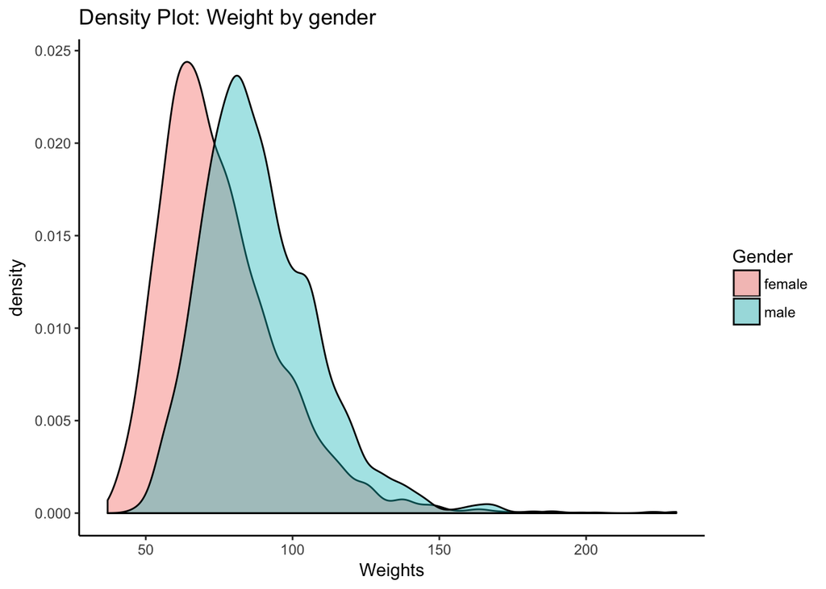

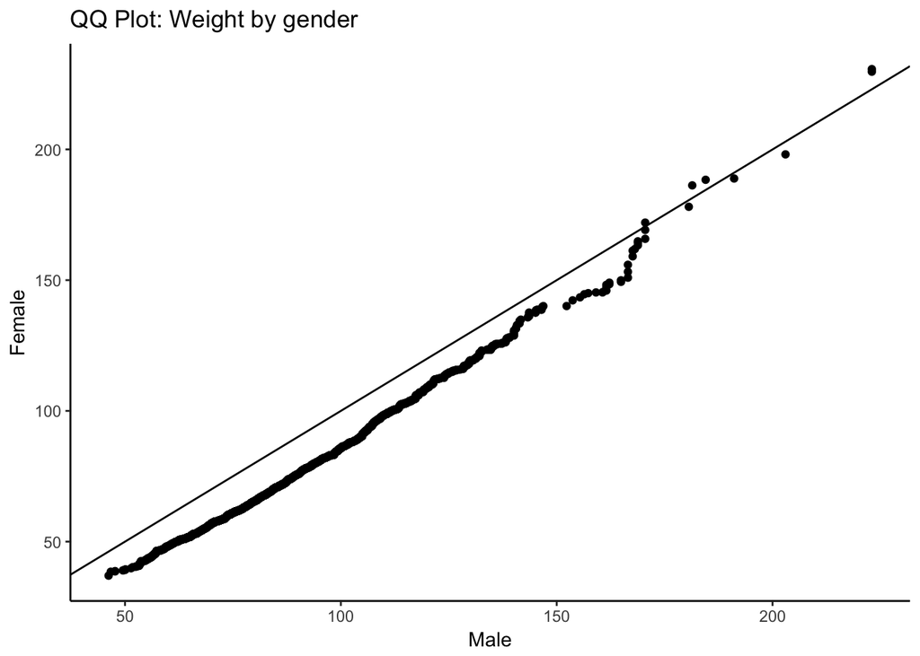

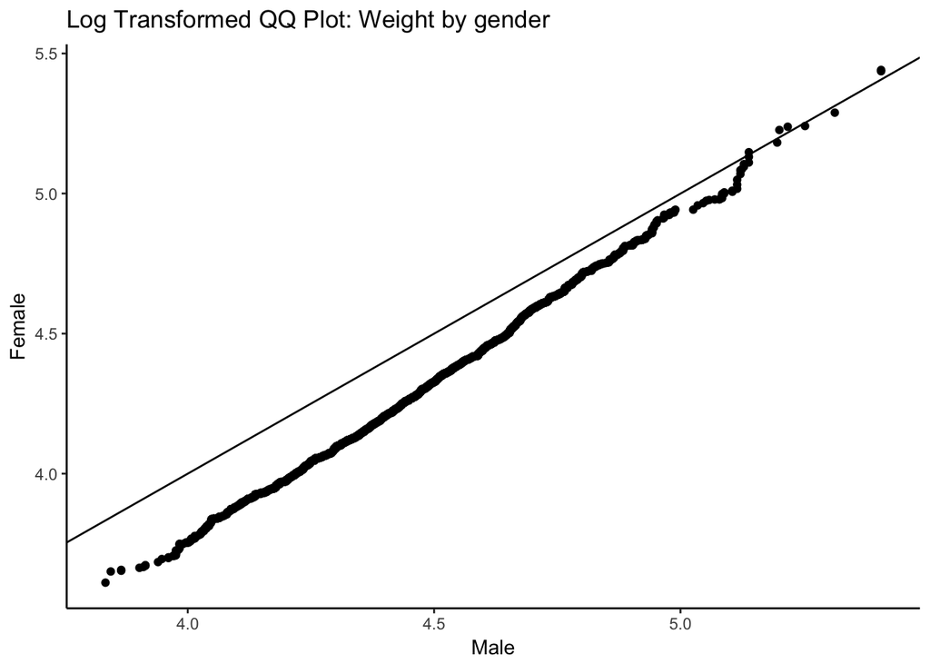

Based on the density, and intial QQ plot (without any transformation) we initially believed that these densities are characterized by an additive shift. However, because of the erratic behaviro seen in the QQ plot as we move towards higher values we wanted to see if a log transformation would alleviate this behavior. The log transformation did not yeild a more parallel, or less erratic relationship between the x=y line and our data. We will rely on our original, non-transformed QQ plot and density plot to conclude that the distribution is well approximated by an additive shift. This is an additive shift because the two distributions (based on the density plot) have the same shape and spread, but different centers. The magnitude of the shift is approximately 15 kg.

# Question 3

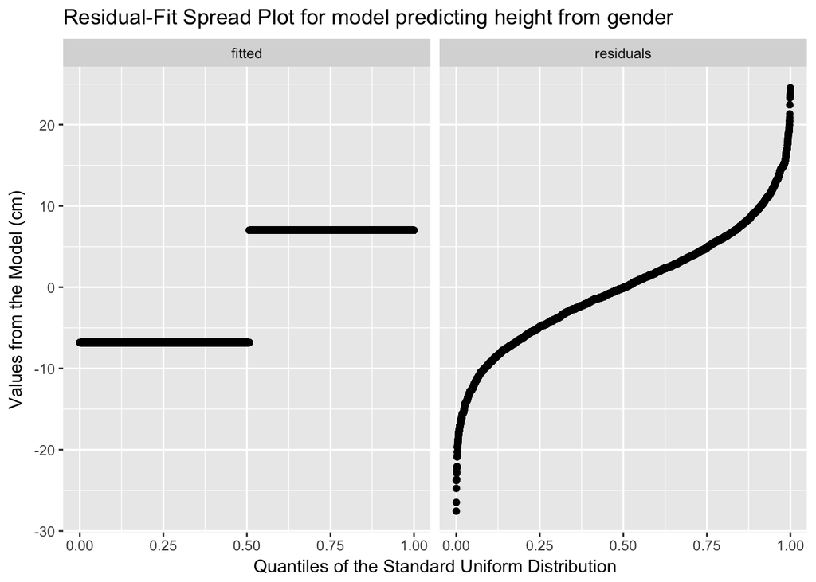

Varaince Captured by the Model has the below value:

```
## [1] 0.4671213
```

Only 47% of the variance is captured by the model. Since so little of the variance is captured when we simply use Gender as an explantory variable, it would be wise to include more explanatory variables to capture this unexplained variance regarding heights. The limited robustness regarding the model’s explanatory power leads us to conclude that this model is not good (though not terrrible). While we don’t necessarily need to entirely discard this model and its results, we do need to recognize that the model is farily limited when it comes to predictions.